# BIOSTAT-M280: Homework #2

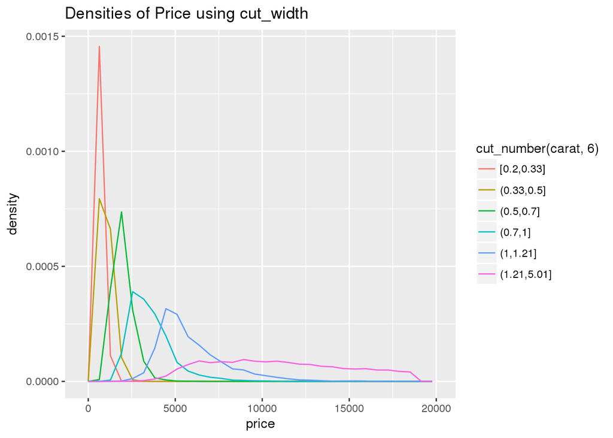

   ```r
         # cut_number to plot density.
       ggplot(data = diamonds,
              mapping = aes(x = price,
                            y = ..density..,
                            colour = cut_number(carat, 6))) +
         geom_freqpoly() +
         ggtitle("Densities of Price using cut_width")
   ```

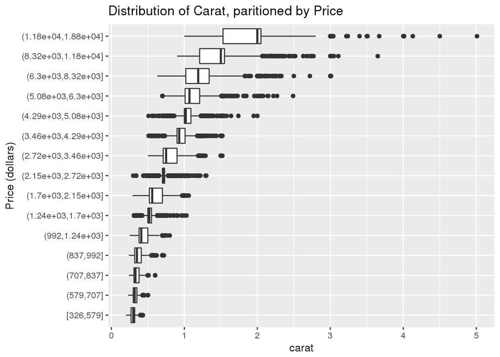

   ```r
     # Paritioning price into 15 bins.
   ggplot(diamonds, aes(x = cut_number(price, 15), y = carat)) +
     geom_boxplot() +
     xlab("Price (dollars)") +
     ggtitle("Distribution of Carat, paritioned by Price") +
     coord_flip()
   ```

   Here we parition the distribution of price into 15 bins with the same number of observations and then use coord_flip to swap the axis. We can clearly see a general increase of price as carat of the diamond increases.
3. How does the price distribution of very large diamonds compare to small diamonds. Is it as you expect, or does it surprise you?

   Refer to the plot from problem 2). The price distribution of diamonds generally increases with size of carat. However, the variance in distribution for larger carat diamonds also increases. This can be suprising at first glance, as you would expect large diamonds to definitely increase in price, always. However, factors like cut and clarity– which can affect price more strongly– may tend to decrease with increasing carat of diamond. (It is rare to find a large carat diamond that is a high quality cut and high clarity). Thus, a diamond can be large in size, but poor in clarity and cut and have lower price than expected.
4. Combine two of the techniques you’ve learned to visualise the combined distribution of cut, carat, and price.

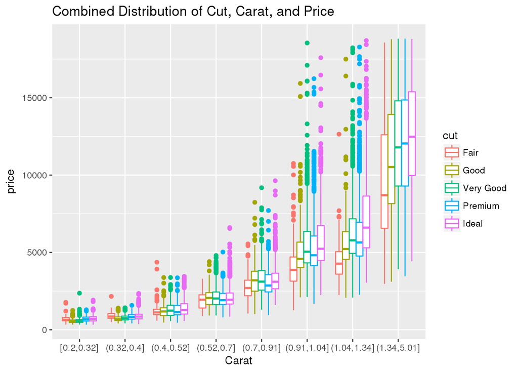

   ```r
   ggplot(data = diamonds, aes(x = cut_number(carat, 8),
                               y = price, color = cut)) +
     geom_boxplot() +
     xlab("Carat") +
     ggtitle("Combined Distribution of Cut, Carat, and Price")
   ```

5. Two dimensional plots reveal outliers that are not visible in one dimensional plots. For example, some points in the plot below have an unusual combination of x and y values, which makes the points outliers even though their x and y values appear normal when examined separately.

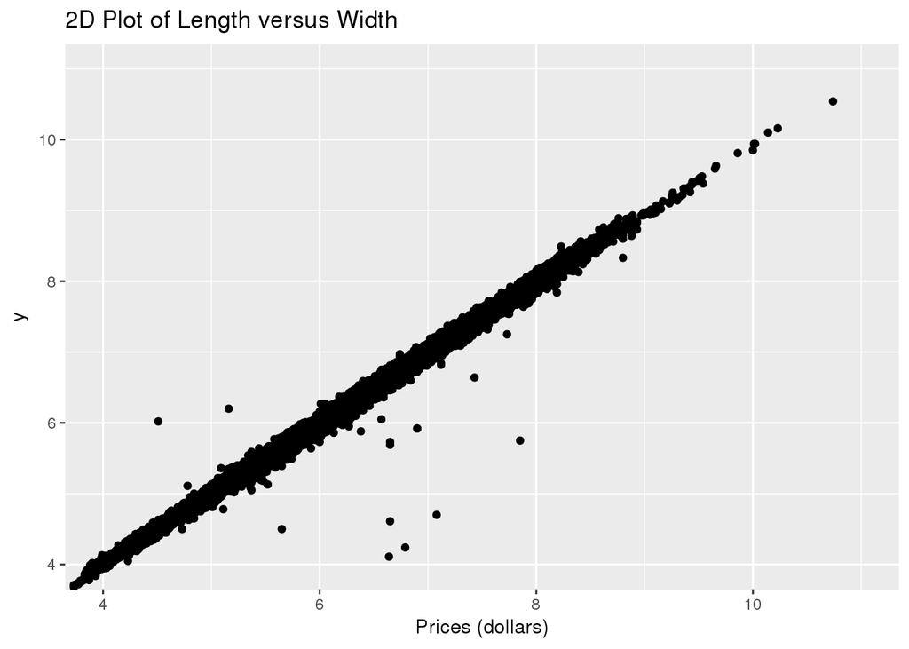

   ```r
     # Two-Dimensional plot of length vs width.
   ggplot(data = diamonds) +
     geom_point(mapping = aes(x = x, y = y)) +
     coord_cartesian(xlim = c(4, 11), ylim = c(4, 11)) +
     xlab("Prices (dollars)") +
     ggtitle("2D Plot of Length versus Width")
   ```

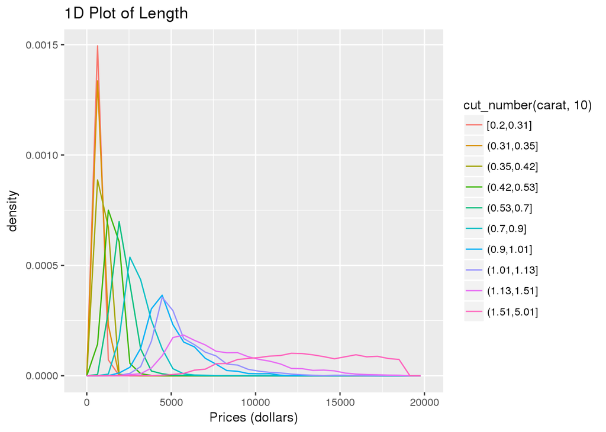

   ```r
     # One-Dimensional plot of length
   ggplot(data = diamonds,
          mapping = aes(x = price,
                        y = ..density..,
                        colour = cut_number(carat, 10))) +
     geom_freqpoly() +
     xlab("Prices (dollars)") +
     ggtitle("1D Plot of Length")
   ```

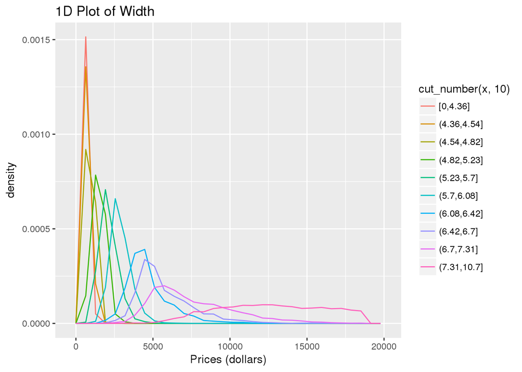

   ```r
     # One-Dimensional plot of width
   ggplot(data = diamonds,
          mapping = aes(x = price,
                        y = ..density..,
                        colour = cut_number(x, 10))) +
     geom_freqpoly() +
     xlab("Prices (dollars)") +
     ggtitle("1D Plot of Width")
   ```

   ```r
     # Note: References made from https://jrnold.github.io/r4ds-exercise-solutions/
   ```

## Q2. Tidyverse Commands

The `35.227.165.60:/home/m280-data/hw1` folder contains a typical genetic data set in plink format. If interested, you can read plink documentation at http://zzz.bwh.harvard.edu/plink/. But it’s definitely not necessary for this homework.

- `merge-geno.bim` contains information of each genetic marker (SNP). Each line is a SNP and has 6 fields:  
  `Chromosome`, `SNP ID`, `Genetic Distance (morgan)`, `Base Pair Position (bp)`, `Allele 1`, `Allele 2`.

  ```bash
  head /home/m280-data/hw1/merge-geno.bim
  ```

  ```
  ## 1    1-54490 0   54490   A   G
  ## 1    1-55550 0   55550   T   A
  ## 1    1-57033 0   57033   C   T
  ## 1    1-57064 0   57064   A   G
  ## 1    1-57818 0   57818   A   C
  ## 1    1-58432 0   58432   C   T
  ## 1    1-58448 0   58448   A   G
  ## 1    1-58814 0   58814   A   G
  ## 1    1-59492 0   59492   G   A
  ## 1    1-60829 0   60829   T   C
  ```

- `merge-geno.fam` contains individual information. Each line is one individual and has 6 fields:  
  `Family ID`, `Person ID`, `Father ID`, `Mother ID`, `Sex` coded as 1 (male) or 2 (female), `Affection Status`  
  `Father ID = 0` means that person’s father is not in this data set. Similarly `Mother ID` = 0 means that person’s mother is not in this data set.

  ```bash
  head -20 /home/m280-data/hw1/merge-geno.fam
  ```

  ```
  ## 2 T2DG0200001 0 0 1 0
  ## 2 T2DG0200002 0 0 2 0
  ## 2 T2DG0200003 0 0 2 0
  ## 2 T2DG0200004 0 0 2 0
  ## 2 T2DG0200005 0 0 1 0
  ## 2 T2DG0200006 0 0 1 0
  ## 2 T2DG0200007 0 0 2 0
  ## 2 T2DG0200008 0 0 2 0
  ## 2 T2DG0200009 0 0 2 0
  ## 2 T2DG0200012 0 0 1 0
  ## 2 T2DG0200013 0 0 1 0
  ## 2 T2DG0200018 0 0 1 0
  ## 2 T2DG0200023 0 0 2 0
  ## 2 T2DG0200024 0 0 1 0
  ## 2 T2DG0200027 0 0 2 0
  ## 2 T2DG0200031 T2DG0200001 T2DG0200015 1 0
  ## 2 T2DG0200032 T2DG0200001 T2DG0200015 2 0
  ## 2 T2DG0200033 T2DG0200001 T2DG0200015 2 0
  ## 2 T2DG0200034 T2DG0200001 T2DG0200015 2 0
  ## 2 T2DG0200035 T2DG0200001 T2DG0200015 2 0
  ```

- `merge-geno.bed` contains genotypes of each individual in binary format. We don’t need this file for this homework.

Please, do **not** put these data files into Git; they are huge. You even don’t need to copy them into your directory. Just read from the data folder `/home/m280-data/hw1` directly.

Use Tidyverse commands to answer following questions.

1. How many persons are in the data set (statisticians call this `n`)?

   ```r
     # Here we are using count to count number of rows in .fam file.
   count(individual)
   ```

   ```
   ## # A tibble: 1 x 1
   ##       n
   ##   <int>
   ## 1   959
   ```

   There are 959 people in the merge-geno.fam data set.

   How many SNPs are in the data set (statisticians call this `p`)?

   ```r
     # Here we are using count to count number of rows in .bim file.
   count(snp)
   ```

   ```
   ## # A tibble: 1 x 1
   ##         n
   ##     <int>
   ## 1 8348674
   ```

   There are 8,348,674 SNPS in the merge-geno.bim data set.
2. Which chromosomes does this data set contain? How many SNPs are in each chromosome?

   ```r
     # Here we are grouping by the Chromosome column and creating a new column Count, with the respective counts with summarise().
   snpCount <- snp %>%
   group_by(Chromosome) %>%
   summarise(count = n())
   snpCount
   ```

   ```
   ## # A tibble: 11 x 2
   ##    Chromosome   count
   ##         <int>   <int>
   ##  1          1 1309299
   ##  2          3 1215399
   ##  3          5 1090185
   ##  4          7  980944
   ##  5          9  732013
   ##  6         11  815860
   ##  7         13  602809
   ##  8         15  491208
   ##  9         17  477990
   ## 10         19  393615
   ## 11         21  239352
   ```

   ```r
     # Setting the working directory.
   dir <- getwd()
   setwd(dir)
     # Here we use the filter command to specify chromosome and Base Pair (BP) specification for the MAP4 gene.
   MAP4 <- snp %>%
   filter(Chromosome == 3, BP >= 47892180, BP <= 48130769) %>%
   summarise(count = n())
   MAP4
   ```

   ```
   ## # A tibble: 1 x 1
   ##   count
   ##   <int>
   ## 1   894
   ```

   There are a total of 894 SNPs located with the MAP4 gene.
4. Statistical geneticists often have to reformat a data set to feed into various analysis programs. For example, to use the Mendel software http://www.genetics.ucla.edu/software/mendel, we have to reformat the data set to be read by Mendel.
   - Mendel’s SNP definition file is similar to the plink `bim` file but has format  
     `SNP ID`, `Chromosome`, `Base Pair Position`  
     with each field separated by a comma. Write a Linux shell command to convert `merge-geno.bim` to Mendel SNP definition file. The first few lines of the Mendel SNP definition file should look like

   ```r
   snpDef <- dplyr::select(snp, SNP.ID, Chromosome, BP)
   line <- paste("    2.40 = FILE FORMAT VERSION NUMBER.\n",
                 "8348674 = NUMBER OF SNPS LISTED HERE.", sep = "")
   write_lines(line, "mendelSnpDef.txt", append = FALSE)
   write_delim(snpDef, "mendelSnpDef.txt",
               delim = ",", col_names = FALSE, append = TRUE)
   ```

   ```bash
   head -10 mendelSnpDef.txt
   ```

   ```
   ##     2.40 = FILE FORMAT VERSION NUMBER.
   ## 8348674 = NUMBER OF SNPS LISTED HERE.
   ## 1-54490,1,54490
   ## 1-55550,1,55550
   ## 1-57033,1,57033
   ## 1-57064,1,57064
   ## 1-57818,1,57818
   ## 1-58432,1,58432
   ## 1-58448,1,58448
   ## 1-58814,1,58814
   ```

   The original merge-geno.bim data set has been converted into a Mendel’s SNP definition file and stored in the text file named mendelSnpDef.txt. Above we preview 10 lines of the mendelSnpDef.txt file.
   - Mendel’s pedigree file is similar to the plink `fam` file but has format  
     `Family ID`, `Person ID`, `Father ID`, `Mother ID`, `Sex` coded as M or F, `Twin Status`  
     with each field separated by a comma. Write a Linux shell command to convert `merge-geno.fam` to Mendel pedigree file. Since twin status is not available in plink format, we put nothing for that field. Also Mendel limits Person ID to have length less than or equal to 8 characters, so we have to strip the string `T2DG` from the IDs. First few lines of the Mendel pedigree should look like

   ```r
   mendPed <- dplyr::select(individual, Family.ID, Person.ID, Father.ID,
                            Mother.ID, Sex)
   mendPed <- mutate(mendPed, Twin.Status = 0)
   mendPed[mendPed == 0] <- NA
   replace_na(mendPed, list(Father.ID = " ", Mother.ID = " ",
                            Twin.Status = " "))

   finalMendPed <- mendPed %>%
    mutate(Sex = if_else(Sex == 2, "F", "M", missing = NULL)) %>%
    mutate(Person.ID = str_replace_all(Person.ID, "T2DG", "")) %>%
    mutate(Father.ID = str_replace_all(Father.ID, "T2DG", "")) %>%
    mutate(Mother.ID = str_replace_all(Mother.ID, "T2DG", ""))
   write_delim(finalMendPed, "mendelPedigree.txt", delim = ",",
               col_names = FALSE, append = FALSE, na = "")
   ```

   ```bash
   head -20 mendelPedigree.txt
   ```

   ```
   ## 2,0200001,,,M,
   ## 2,0200002,,,F,
   ## 2,0200003,,,F,
   ## 2,0200004,,,F,
   ## 2,0200005,,,M,
   ## 2,0200006,,,M,
   ## 2,0200007,,,F,
   ## 2,0200008,,,F,
   ## 2,0200009,,,F,
   ## 2,0200012,,,M,
   ## 2,0200013,,,M,
   ## 2,0200018,,,M,
   ## 2,0200023,,,F,
   ## 2,0200024,,,M,
   ## 2,0200027,,,F,
   ## 2,0200031,0200001,0200015,M,
   ## 2,0200032,0200001,0200015,F,
   ## 2,0200033,0200001,0200015,F,
   ## 2,0200034,0200001,0200015,F,
   ## 2,0200035,0200001,0200015,F,
   ```